# Project (Signature Assignment)

# Model 5 - Random Forest

#### Using “randomforest” package & randomForest() function

```r
library(randomForest)
model_RF <- randomForest(credit_training$Class ~., data = credit_training)
summary(model_RF)
```

```
                Length Class  Mode
call                 3 -none- call
type                 1 -none- character
predicted        53403 factor numeric
err.rate          1500 -none- numeric
confusion            6 -none- numeric
votes           106806 matrix numeric
oob.times        53403 -none- numeric
classes              2 -none- character
importance          30 -none- numeric
importanceSD         0 -none- NULL
localImportance      0 -none- NULL
proximity            0 -none- NULL
ntree                1 -none- numeric
mtry                 1 -none- numeric
forest              14 -none- list
y                53403 factor numeric
test                 0 -none- NULL
inbag                0 -none- NULL
terms                3 terms  call
```

```r
print(model_RF)
```

```
Call:
 randomForest(formula = credit_training$Class ~ ., data = credit_training)
               Type of random forest: classification
                     Number of trees: 500
No. of variables tried at each split: 5

        OOB estimate of  error rate: 0.07%
Confusion matrix:
      0  1  class.error
0 53304  6 0.0001125492
1    32 61 0.3440860215
```

```r
pred_RF <- predict(model_RF, credit_testing_fulldata)
```

#### Evaluation of the model with Absolute Accuracy and AUC - Random Forest against the testing dataset; which is partitioned on full dataset.

```r
confusionMatrix(pred_RF, credit_testing_fulldata$Class) #Evaluation (Accuracy: 0.9996, No Information Rate: 0.9983)
```

```
Confusion Matrix and Statistics

          Reference
Prediction     0     1
         0 71077    27
         1     1    96

               Accuracy : 0.9996
                 95% CI : (0.9994, 0.9997)
    No Information Rate : 0.9983
    P-Value [Acc > NIR] : < 2.2e-16

                  Kappa : 0.8725
 Mcnemar's Test P-Value : 2.306e-06

            Sensitivity : 1.0000
            Specificity : 0.7805
         Pos Pred Value : 0.9996
         Neg Pred Value : 0.9897
             Prevalence : 0.9983
         Detection Rate : 0.9983
   Detection Prevalence : 0.9986
      Balanced Accuracy : 0.8902

       'Positive' Class : 0
```

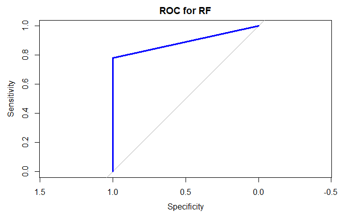

```r
library(pROC)
roc_RF <- roc(as.numeric(test_class_fulldata), as.numeric(pred_RF))
plot.roc(roc_RF, col="Blue", lwd=3, main = "ROC for RF")
```

```r
auc(roc_RF) #Area under the curve: 0.8902298
```

```
Area under the curve: 0.8902
```

# Model 6 - Support Vector Machine

#### Using “kernlab” package & “ksvm()” function

```r
library(kernlab)
model_SVM <- ksvm(credit_training$Class ~ ., data = credit_training, kernel = "rbfdot")
model_SVM
```

```
Support Vector Machine object of class "ksvm"

SV type: C-svc  (classification)
 parameter : cost C = 1

Gaussian Radial Basis kernel function.
 Hyperparameter : sigma =  0.0298576596945099

Number of Support Vectors : 1222

Objective Function Value : -111.2471
Training error : 0.000412
```

```r
pred_SVM <- predict(model_SVM, credit_testing_fulldata)
```

```r
auc(roc_SVM)
```

[output not shown]

```
Area under the curve: 0.7967
```

### (o) Comparing/Evaluating Accuracy of individually created models using AUC/ROC:

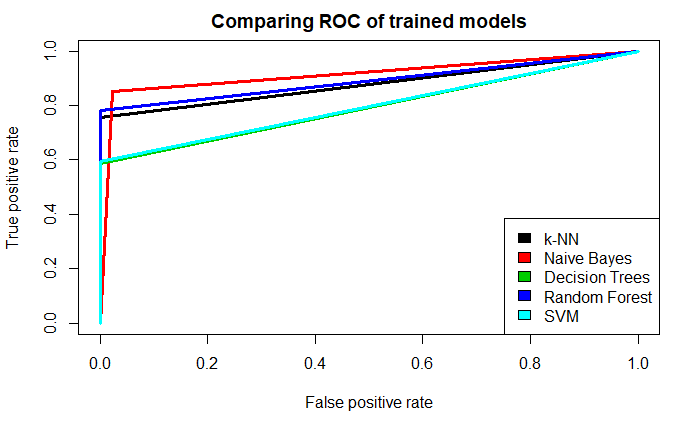

```r
library(ROCR)
predictions_list <- list(as.numeric(pred_knn), as.numeric(pred_NB),as.numeric(pred_Dec.trees),as.numeric(pred_RF),as.numeric(pred_SVM))
d <- length(predictions_list)
actualsvalue_list <- rep(list(as.numeric(credit_testing_fulldata$Class)), d)
frame <- prediction(predictions_list, actualsvalue_list)
rocs_frame <- performance(frame, "tpr", "fpr")
plot(rocs_frame, col = as.list(1:d), main = "Comparing ROC of trained models", lwd=3 , pch=17)
legend("bottomright", c("k-NN","Naive Bayes","Decision Trees", "Random Forest", "SVM"), fill = 1:d)
```

#### After analyzing the evaluation of our individually constructed model by Absolute Accuracy and AUC, we’ve decided to perform further detailed evaluation and improvement on just 3 machine learning predictive models.

#### Brief:- Evaluating best 3 from amongst 6 trained models

#### They are: (1) k-Nearest Neighbor, (2) Naive Bayes & (3) Random Forest

#### We’ll perform each and every techniques and methods to build the model as per the requirement and ensure the success after deployment of the same.

#### Considering and ease to understand, we’ll try to perform each techniques/steps seperately under each specific model.

# Phase - 5: Evaluation:

#### Let’s create partitions on the dataset. We will work on sample (i.e. 25% of the full dataset), since we are require to train the model and we will apparently do using the same ans we’ve performed before above.

#### We’ll partition it in 50%-Training, 25%-Testing & rest 25%-Validation

```r
set.seed(723)
split <- sample(1:3, size=nrow(dataf3), replace=TRUE, prob=c(0.5,0.25,0.25))
handout_train <- dataf3[split == 1,]      #Used to train the model
handout_test <- dataf3[split == 2,]
handout_validation <- dataf3[split == 3,]
dim(handout_train)
```

```
[1] 35570    31
```

```r
dim(handout_test)
```

```
[1] 17806    31
```

```r
dim(handout_validation)
```

```
[1] 17826    31
```

```r
prop.table(table(handout_train$Class))
```

```
          0           1
0.998088277 0.001911723
```

```r
prop.table(table(handout_test$Class))
```

```
          0           1
0.998371336 0.001628664
```

```r
prop.table(table(handout_validation$Class))
```

```
          0           1
0.998541456 0.001458544
```

```r
#Seperating features and class for training dataset; we are going to use.
handout_train_features <- handout_train[,1:30]
handout_train_class <- handout_train[,31]
```

#### Here after, Dataset is partitioned into three seperate dataset from amongst which, we’ll perform training of a model on handout_training, testing on “handout_test” and again perform testing on “handout_validation” (i.e. to determine if the model performance is generalized and not overfitting/underfitting by any chance) and if there seems an issue of fitting of the model on the testing datasets then we must have to avoid using it of improved it in way to ignore such failures.

#### In order to be more precise about the results, we’ll partition the same proportion of the dataset for full dataset (i.e original) and use the testing and validation data given by them.

```r
set.seed(723)
split_fulldata <- sample(1:3, size=nrow(dataf3_fulldata), replace=TRUE, prob=c(0.5,0.25,0.25))
handout_train_fulldata <- dataf3_fulldata[split == 1,]
handout_test_fulldata <- dataf3_fulldata[split == 2,]        #Used to test the model
handout_validation_fulldata <- dataf3_fulldata[split == 3,]  #Used to test the model
dim(handout_train_fulldata)
```

```
[1] 142280     31
```

```r
dim(handout_test_fulldata)
```

```
[1] 71223    31
```

```r
dim(handout_validation_fulldata)
```

```
[1] 71304    31
```

```r
prop.table(table(handout_train_fulldata$Class))
```

```
          0           1
0.998369412 0.001630588
```

```r
prop.table(table(handout_test_fulldata$Class))
```

```
          0           1
0.998258989 0.001741011
```

```r
prop.table(table(handout_validation_fulldata$Class))
```

```
          0           1
0.998092674 0.001907326
```

```r
#Seperating features and class for testing data; which we are going to use
handout_test_features <- handout_test_fulldata[,1:30]
handout_test_class <- handout_test_fulldata[,31]
#Seperating features and class for validation data; which we are going to use
handout_validation_features <- handout_validation_fulldata[,1:30]
handout_validation_class <- handout_validation_fulldata[,31]
```